# Praca domowa 5

Michał Pastuszka

29 - 04 - 2019

# 1 Wstęp

W tym zadaniu przetestujemy działanie drzew decyzyjnych w zależności od wybranych hiperparametrów na przykładzie zbioru Titanic z Kaggle: https://www.kaggle.com/c/titanic/data

```r
head(titanic)
```

|  | PassengerId | Survived | Pclass | Name | Sex | Age | SibSp | Parch | Ticket | Fare | Cabin | Embarked |
| --- | --- | --- | --- | --- | --- | --- | --- | --- | --- | --- | --- | --- |
| 1 | 1 | 0 | 3 | Braund, Mr. Owen Harris | male | 22 | 1 | 0 | A/5 21171 | 7.2500 |  | S |
| 2 | 2 | 1 | 1 | Cumings, Mrs. John Bradley (Florence Briggs Thayer) | female | 38 | 1 | 0 | PC 17599 | 71.2833 | C85 | C |
| 3 | 3 | 1 | 3 | Heikkinen, Miss. Laina | female | 26 | 0 | 0 | STON/O2. 3101282 | 7.9250 |  | S |
| 4 | 4 | 1 | 1 | Futrelle, Mrs. Jacques Heath (Lily May Peel) | female | 35 | 1 | 0 | 113803 | 53.1000 | C123 | S |
| 5 | 5 | 0 | 3 | Allen, Mr. William Henry | male | 35 | 0 | 0 | 373450 | 8.0500 |  | S |
| 6 | 6 | 0 | 3 | Moran, Mr. James | male | NA | 0 | 0 | 330877 | 8.4583 |  | Q |

Zaczniemy od usunięcia niepotrzebnych kolumn: “PassengerId”, “Name”, “Ticket”, “Cabin”.

```r
titanicClean <- titanic[,!colnames(titanic)%in%c("PassengerId", "Name", "Ticket", "Cabin")]
```

Zajmować będziemy się parametrami:

- cp - complexity: zabrania tworzenie podziałów, które zwiększyłyby miarę R-squared o mniej niż jego wartość
- maxdepth - maksymalna głębokość drzewa
- minbucket - minimalna liczba obserwacji w liściu
- minsplit - minimalna liczba obserwacji dla której można dokonać podziału node’a

# 2 Porównanie

Porównania będziemy dokonywać na ustalonym podziale danych, korzystając z miary AUC.

```r
trainTestSplit <- sample(nrow(titanicClean), size = nrow(titanicClean)*0.7)
trainSet <- titanicClean[trainTestSplit,]
testSet <- titanicClean[-trainTestSplit,]
trainTask <- makeClassifTask("Titanic", trainSet, "Survived")
testTask <- makeClassifTask("Titanic", testSet, "Survived")
```

## 2.1 Domyślne parametry

Zaczniemy od utworzenia drzewa korzystając z domyślnych parametrów w pakiecie: cp = 0.01, maxdepth = 30, minbucket = 7, minsplit = 20.

```r
learner <- makeLearner("classif.rpart", predict.type = "prob")
trained <- train(learner, trainTask)
prediction <- predict(trained, testTask)
ROCmeasures <- calculateROCMeasures(prediction)
measureAUC(prediction$data$prob.1, truth = prediction$data$truth, positive = "1")
```

```
## [1] 0.787983
```

## 2.2 Proponowane parametry

Teraz przetestujemy parametry proponowane w artykule “Tunability: Importance of Hyperparameters of Machine Learning Algorithms” ( https://arxiv.org/pdf/1802.09596.pdf ): cp = 0, maxdepth = 21, minbucket = 12, minsplit = 24

```r
learnerPr <- makeLearner("classif.rpart", predict.type = "prob", par.vals = list(cp = 0, maxdepth = 21, minbucket = 12, minsplit = 24))
trainedPr <- train(learnerPr, trainTask)
predictionPr <- predict(trainedPr, testTask)
measureAUC(predictionPr$data$prob.1, truth = predictionPr$data$truth, positive = "1")
```

```
## [1] 0.7921205
```

## 2.3 Wyszukiwanie losowe

Spróbujemy teraz dobrać do naszego zbioru optymalne parametry metodą random search wykonując 1000 iteracji.

```r
learnerRa <- makeLearner("classif.rpart", predict.type = "prob")

tunedParams <- tuneParams(learner = learner,
                       task = trainTask, resampling = makeResampleDesc("CV", iters = 5),
                       measures = list(auc), control = makeTuneControlRandom(maxit = 1000),
                       par.set = makeParamSet(
                         makeNumericParam("cp", lower=0, upper=1),
                         makeIntegerParam("maxdepth", lower=1, upper=30),
                         makeIntegerParam("minbucket", lower=1, upper=60),
                         makeIntegerParam("minsplit", lower=1, upper=60)))
print(tunedParams)
```

```
## Tune result:
## Op. pars: cp=0.00651; maxdepth=24; minbucket=10; minsplit=43
## auc.test.mean=0.8429712
```

```r
learnerRa <- setHyperPars(learnerRa, par.vals = tunedParams$x)
trainedRa <- train(learnerRa, trainTask)
predictionRa <- predict(trainedRa, testTask)
measureAUC(predictionRa$data$prob.1, truth = predictionRa$data$truth, positive = "1")
```

```
## [1] 0.7851841
```

Okazuje się, że znalezione parametry wypadły gorzej niż oba poprzednie proponowane ustawienia. Najlepszymi okazały się więc parametry proponowane w artykule.

## 2.4 Conditional Inference Trees

Porównamy wyniki dla tradycjnych drzew z drzewem typu Conditional Inference z pakietu `partykit`, korzystając z domyślnych parametrów.

```r
learnerCt <- makeLearner("classif.ctree", predict.type = "prob")
trainedCt <- train(learnerCt, trainTask)
predictionCt <- predict(trainedCt, testTask)
measureAUC(predictionCt$data$prob.1, truth = predictionCt$data$truth, positive = "1")
```

```
## [1] 0.8336173
```

Okazuje się, że drzewo tego typu sprawdziło się znacznie lepiej niż poprzednie.

# 3 Wynikowe drzewo

Narysujemy teraz najlepsze utworzone drzewo decyzyjne `rpart`, korzystające z proponowanych w artykule parametrów:

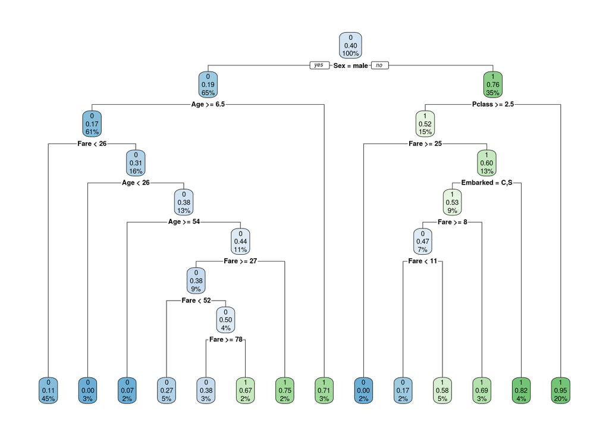

```r
rpart.plot(trainedPr$learner.model, roundint = FALSE)
```

Oraz drzewo `ctree`:

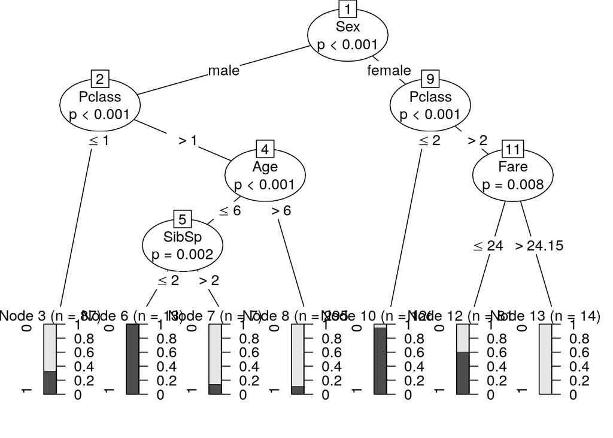

```r
plot(trainedCt$learner.model)
```

Możemy zauważyć, że drugie drzewo jest znacznie płytsze niż pierwsze. Poza tym, pierwsze drzewo posiada bardzo wiele podziałów opartych o zmienne `Fare` i `Age`, podczas gdy w drugim pojawiają się one tylko po razie.